# Phy 491 HW 2

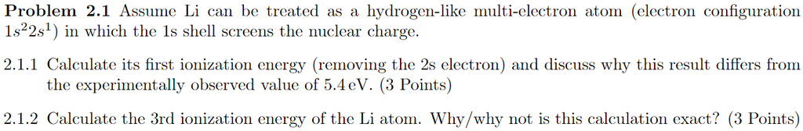

2.1.1

If we assume the first two $1s$ electrons completely screen out $2e^+$ from the nucleus and leave $z=1$, our calculations would be the same as hydrogen only with a greater central mass, and end up pretty close to $13.6eV$ However, the 2s electron is in the second energy level, so using the energy eigenvalue equation for hydrogen

$$E_n = -\frac{1}{2 (n)^2} \left( \frac{Ze^2}{4\pi\epsilon_0}\right)^2 \frac{m_e c^2}{\hbar^2} $$

the energy eigenvalue for the orbital would actually be

$$ E_2 = -\frac{1}{8} \left(\frac{1*e^2}{4\pi\epsilon_0} \right)^2\frac{m_e c^2}{\hbar^2} = -\frac{1}{4}*13.6eV = -3.4eV $$

This is smaller than the experimentally ovserved value due to the assumptions we used. Particularly, the assumption that the nucleus is fully shielded by the $1s$ electrons. The $2s$ orbital actually is partially beneath the $1s$ orbital, so the actual charge seen by the $2s$ electron is greater.

2.1.2 Using the eigenvalue equation above and the fact that this electron is in the $1s$ orbital, this yields

$$E_1 = -\frac{1}{2} \left( \frac{3e^2}{4\pi\epsilon_0}\right)^2 \frac{m_e c^2}{\hbar^2} = -\frac{3^2}{1}*13.6 eV= -122.4eV $$

The calculation is exact at least to the decimal value we're concerned about. The shielding effect is no longer in place and there aren't any electron-electron interactions now.

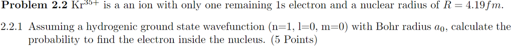

$\text{Kr}^{35+}$ is quite ionized.

Assuming a hydrogen Bohr radius $a_0$ and hydrogenic ground state, we can use the radial wave function equation found in Mcintyre (and various neat tables) to approximate the wave function.

$$ \int_V |\Psi_{100}|^2 dV = 4\pi \int_0^{R} r^2 \left[ \frac{1}{\sqrt{\pi}} \left(\frac{Z}{a_0} \right)^{3/2} e^{-Zr/a_0} \right]^2 dr \\ = 4\left(\frac{Z}{a_0}\right)^3 \int_0^R r^2 e^{-2Zr/a_0} dr $$

By the power of Wolfram

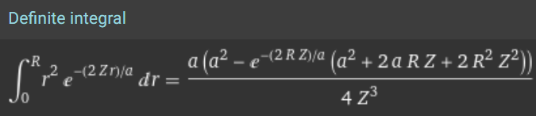

$$ = \frac{1}{a_0^3} \left[a_0^3 - a_0 e^{-2RZ/a_0} (a_0^2 + 2a_0 R Z + 2R^2 Z^2) \right] \\ = 1 - e^{-2RZ/a_0} \left(1+\frac{2RZ}{a_0} + \frac{2R^2Z^2}{a_0^2} \right) $$

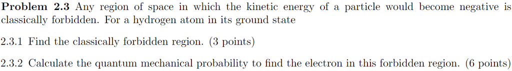

Classically forbidden: $KE<0$

2.3.1

An electron in its ground state has total energy $E_1 = -13.6eV$, so the classically forbidden region is anywhere where potential energy is $-13.6eV$ or greater. This occurs for $U(r) = -\frac{ke^2}{r} > -13.6eV$ aka beyond the bohr radius $a_0 = 52.9*10^{-12}m$

2.3.2

This is the portion of the wavefunction where $r>a_0$, so piggybacking off our previous formulas

$$ \int_V |\Psi_{100}|^2 dV = 4\left(\frac{Z}{a_0}\right)^3 \int_{a_0}^\infty r^2 e^{-2Zr/a_0} dr $$

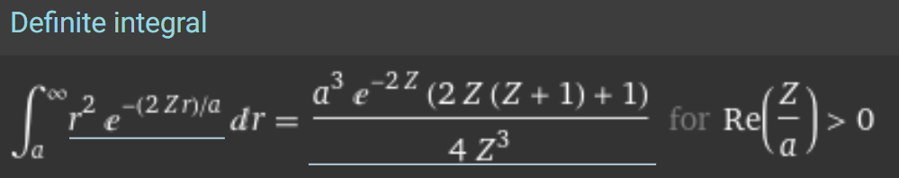

$$ = e^{-2Z}(2Z^2+2Z+1) = 5e^{-2} = 0.677 $$

A $67.7\%$ chance. Somewhat unexpected for me but I can reconcile it. In order to have an average value of $a_0$, it isn't just that there's even probability that the electron is on either side of $a_0$.

The probability curve is skewed and the exponential drop in value $e^{-Zr/a}$ means that most of the remaining area under the curve is closer to the mean, and the data left of the mean is further away and requires less area to pull it's half of the values down. Hence the difference in probabilites above/below the mean value.